# Ram Rules!

Dakota Cintron

May 3, 2017

# Timeline of Models for the Structural Analysis of Moment Structures

- Spearman’s one factor model (1904)
- Thurstone’s (1947) multiple-factor model
- Anderson and Rubin’s (1956) restricted oblique common factor model
- Bock & Bargmann’s (1966) introduction of a group of models for the analysis of covariance structures
- Jöreskog’s (1970) expansion of Bock & Bargmann’s work to the general analysis of covariance structures (ACOVS)
  - Did not allow for a patterned invese matrix
- Jöreskog’s (1973) linear structural relations (LISREL) model
  - Capitalized on work by Keesling and Wiley (Wiley, 1973) which showed that a patterned inverse was necessary for in a general-purpose model for multivariate analysis
- Bentler’s (1976) development of the m-th order factor model
  - Does not allow for a patterned inverse matrix
- McDonald’s (1978) covariance structural analysis model (COSAN)
  - m-th order model in which a patterned inverse matrix can be specified
  - ACOVS model when no patterned inverse matrix is necessary (McArdle, 2005)
- McArdle’s (1978) Reticular Action Model
  - Second order model with an patterned inverse option

# The Reticular Action Model (RAM)

- A model for the structural analysis of moment structures
- Designed to “simplfy and unify structural equation models (McArdle, 2005)”
  - COSAN and LISREL special cases & generalizations of RAM
- Based on path analysis graphics
- Mathematical Representation of RAM presentated as:
  - A second-order moment (i.e. $\Sigma$) structure model with two parameter matrices ($\textrm{A}$ & $\Omega$)
- The A is represented in the RAM through a patterned inverse matrix
  - The term patterned here means that any element of a matrix can be defined with constants, paramaters to be freely estimated, or parameters which are constrained to be equal (McArdle, 2005; McArdle & McDonald, 1984)
- Definitions and axioms outlined in McArdle (2005) provide isomorphism between RAM notation, graphics, and algebra

# History RAM

- McArdle (2005) provides detailed outline of RAM and its development
- RAM rules initially presented between 1978-1981
- McArdle used classical ideas and respective software related to linear structural relations (LISREL; Jöreskog, 1973) and covariance structure analysis (COSAN; McDonald, 1978) to develop RAM
  - Also, used graphic concepts from latent variable path analysis (Wright, 1934; Wold, 1980)
- The Reticular Action nomenclature was chosen to recognize work done by Raymond Cattell (1965,1978)
  - Cattell promoted a general system which included manifest and latent variances in a free-form network of aymmetric and symmetric action
  - Thefree-form network of asymmetric and symmetric action was termed the ‘reticule’

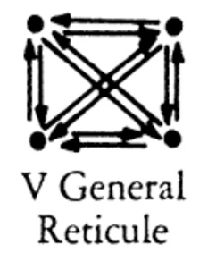

Handbook of Multivariate Experimental Psychology (Nesselroade & Cattell, 1966)

# RAM

$$\textrm{v = Av + u}$$

- $\textrm{v}$ is a *t* x 1 vector of random variables
- $\textrm{A}$ is a square matrix which represents the structural relationship (i.e. directed or asymmetric) between row variable $\textrm{v}_{i}$ and column variable $\textrm{v}_{j}$
- $\textrm{u}$ represents the residual
- Generalization of Guttman’s (1953) image theory
  - $\textrm{Av}$ are the images of *t* variables in terms of *t*-1 other variables
  - Components of $\textrm{u}$ are the anti-images

# $\Omega$ Matrix

$$\Omega = E[\textrm{uu}']$$

- *t* x *t* matrix
- Each element of $\Omega$, $\omega_{ij}$, represents an undirected or symmetric structural relation among residual variables $\textrm{u}_{i}$ and $\textrm{u}_{j}$
- If no relationship among $\textrm{u}_{i}$ and $\textrm{u}_{j}$ $\omega_{ij}$ = 0

# $\Sigma$ Matrix

- In order to define the moments among the variables, in terms of structural parameters, the following *t* x *t* matrix must be defined as below
- Here, every element of $\Sigma$ represents the association among the variables $\textrm{v}_{i}$ and $\textrm{v}_{j}$

$$\Sigma = E[\textrm{vv}']$$

# Moment Structure Matrix

- $\textrm{I}_{t}$ is a *t* x *t* identity matrix
- We can re-write the RAM model as:

$$\textrm{u = v - Av} = (\textrm{I}_{t} - \textrm{A)v}$$

- As a result, we can write:

$$\Omega = (\textrm{I}_{t} - \textrm{A})\Sigma(\textrm{I}_{t} - \textrm{A})'$$

- Moreover, with the above definitions, we can now write the $\textrm{v}$ variables in terms of the residual structural relations:

$$\textrm{v} = (\textrm{I}_{t} - \textrm{A})^{-1}\textrm{u}$$

- Which yields the *moment structure model* for all variables $\textrm{v}$:

$$\Sigma = (\textrm{I}_{t} - \textrm{A})^{-1}\Omega(\textrm{I}_{t} - \textrm{A})^{-1'}$$

- $\Sigma$ a function of A (i.e. patterned inverse) and $\Omega$ (i.e. matrix of undirected or symmetric structural relations among residual variables u$_{i}$ and u$_{j}$

# Manifest and Latent Variables

In the RAM model, $\textrm{v}$ is partitioned into two subvectors $\textrm{m}$ of *j* components, and $\ell$, of k components where *j* + *k* = *t*:

$$\textrm{v}' = [\textrm{m}, \ell]'$$

- $\textrm{m}$ manifest variables
- $\ell$ latent or unobserved variables

# Filter Matrix

- $_{j}\textrm{O}_{k}$ is a null matrix (i.e. all 0’s)
- In order to distinguish between manifest and latent variables, the following filter matrix is defined:

$$F = [\textrm{I}_{j} : _{j}\textrm{O}_{k}]$$

Where $_{j}\textrm{O}_{k}$ is a *j* x *k* matrix so that:

$$\textrm{m = Fv}$$

- F is a matrix of 0’s and 1’s that selects or filters the manifest variables out of v (i.e. the set of manifest and latent variables)
- We will see later that in the RAMpath program F is not essentially to define as the program automates it’s construction based on model definitions
- If positions of variables in v are permutated, that is the $\textrm{m}$ and $\ell$ are switched, the F matrix can correspondngly be permuted

# Moment Structure Matrix for Manifest Variables

- Let us define the moment structure matrix for manifest variables as:

$$\Sigma_{mm} = E[\textrm{mm}']$$

- $\Sigma_{mm}$ is a general raw product-moment matrix (note: $\Sigma_{mm}$ is a covariance matrix if all manifest variables have means of zero).
- Using $\textrm{v} = (\textrm{I}_{t} - \textrm{A})^{-1}\textrm{u}$ and $\textrm{m = Fv}$ we can define:

$$\textrm{m} = \textrm{F}(\textrm{I}_{t} - \textrm{A})^{-1'}\textrm{u}$$

- The moment sructure among manifest variables is then:

$$\Sigma_{mm} = \textrm{F}\Sigma\textrm{F}' = \textrm{F}(\textrm{I}_{t} - \textrm{A})^{-1}\Omega(\textrm{I}_{t} - \textrm{A})^{-1'}\textrm{F}'$$

# Interrelationship Among the RAM and LISREL (McArdle, 2005)

- Recall that the Linear Strucutral Relations (LISREL; Jöreskog, 1973) can be defined using the following definitions:
  - $x = \Lambda_{x}\xi + \delta$
  - $y = \Lambda_{y}\eta + \epsilon$
  - $\textrm{B}\eta = \Gamma\xi + \zeta$
  - $\textrm{x}$ (p x 1)
  - $\textrm{y}$ (q x 1)
  - $\Gamma$ (n x 1)
  - $\xi$ (m x 1)
- With expectations
  - $\Sigma_{\zeta\zeta} = \Psi$
  - $\Sigma_{\epsilon\epsilon} = \Theta_{\epsilon}$
  - $\Sigma_{\delta\delta} = \Theta_{\delta}$
  - $\Sigma_{\xi\xi} = \Phi$
- McArdle (1984) showed, we can write the LISREL model in RAM notation as:

$$\begin{bmatrix}\textrm{y} \\\textrm{x} \\\end{bmatrix} = \begin{bmatrix}\textrm{I} & 0 & 0 & 0 \\0 & \textrm{I} & 0 & 0 \\\end{bmatrix}\begin{bmatrix}\textrm{I} & 0 & -\Lambda_{y} & 0 \\0 & \textrm{I} & 0 & -\Lambda{x} \\0 & 0 & \textrm{B} & -\Gamma \\0 & 0 & 0 & \textrm{I} \\\end{bmatrix}^{-1}\begin{bmatrix}\epsilon \\\delta \\\zeta \\\xi\\\end{bmatrix}$$

- By defining the following:
  - $j = p + q$,
  - $k = n + m$,
  - $\textrm{v}'= [y'x'\eta'\xi']$,
  - $\textrm{u}'= [\epsilon'\delta'\zeta'\xi']$

$$\textrm{A} = \begin{bmatrix}
0 & 0 & \Lambda_{y} & 0 \\
0 & 0 & 0 & \Lambda{x} \\
0 & 0 & \textrm{(I-B)} & \Gamma \\
0 & 0 & 0 & 0 \\
\end{bmatrix}$$

$$\Omega = \begin{bmatrix}
\Theta_{\epsilon\epsilon} & & & \\
0 & \Theta_{\delta\delta} & & \\
0 & 0 & \Psi & \\
0 & 0 & 0 & \Phi \\
\end{bmatrix}$$

Where,

- $\Sigma_{\zeta\zeta} = \Psi$
- $\Sigma_{\epsilon\epsilon} = \Theta_{\epsilon}$
- $\Sigma_{\delta\delta} = \Theta_{\delta}$

$$\textrm{E} = (\textrm{I-A})^{-1} =
\begin{bmatrix}
\textrm{I} & 0 & \Lambda_{y}\textrm{B}^{-1} & \Lambda_{y}\textrm{B}^{-1}\Gamma \\
0 & \textrm{I} & 0 & \Lambda_{x} \\
0 & 0 & \textrm{B}^{-1} & \textrm{B}^{-1}\Gamma \\
0 & 0 & 0 & 0 \\
\end{bmatrix}$$

$$F = \begin{bmatrix}
\textrm{I} & 0 & 0 & 0 \\
0 & \textrm{I} & 0 & 0 \\
\end{bmatrix}$$

# Notes on the RAM

- Everything done so far has been in regards to the Algebraic Representation of the RAM
  - The Graphical Representation of the RAM is presented next via examples in R
  - McArdle (2005) also provides a Computational Representaion of the RAM
- RAM provides an economical and simplistic presentation of a variety of statistical models (e.g. Multiple Linear Regression, Path Analysis, and factor analysis)
- “Necessary and sufficient” notation for general SEM (McArdle, 2005)
- Ram Terminology (will need soon)
  - Arrows
  - Slings
- The notation above really unnecessary
  - All models can be defined and fit in terms of arrows and slings

# *RAMpath* R package (Zhang, Hamagami, Grimm, & McArdle, 2015)

Package *RAMpath*

```r
lsp(RAMpath)
```

```
##  [1] "lavaan2ram"    "powerBLCS"     "powerLCS"      "ram2lavaan"
##  [5] "ramBLCS"       "ramEffectSE"   "ramFit"        "ramLCM"
##  [9] "ramLCS"        "ramMatrix"     "ramPathBridge" "ramReFit"
## [13] "ramShowModel"  "ramUniquePath" "ramVF"
```

# RAMpath Datasets

- Datasets in the *RAMpath* package
- Useful for gaining familiarity with *RAMpath* package

```r
names(ex1)
```

```
## [1] "age"  "hvlt" "ept"
```

```r
names(ex2)
```

```
## [1] "edu"    "gender" "ws1"    "ls1"    "lt1"
```

```r
names(ex3)
```

```
##  [1] "X1"  "X2"  "X3"  "X4"  "X5"  "X6"  "Y7"  "Y8"  "Y9"  "Y10" "Y11"
## [12] "Y12"
```

# RAMpath Model Definition Example 1

- Mediation model
- Does HVLT mediate the relationship between age and ept?

```r
# Model definition
m1<-'
manifest=3
label=age,hvlt,ept
arrow(2,1)=?
arrow(3,1)=?
arrow(3,2)=?
sling(1,1)=?
sling(2,2)=?
sling(3,3)=?
'
```

- Define arrows and slings
- ?, notation freely estimates parameter
- ? 1.0, notation will provide a starting value for parameter estimation
- @ 1.0, notation will constrain parameter value to specific value

# Estimation of Model Parameters

- Estimation is carried out in *lavaan* package
- Results given in RAM notation
- Note $\textrm{S}$ matrix is equivalent to $\Omega$ matrix

```r
res1 <- ramFit (m1, ex1)
```

```
##
## --------------------
## Parameter estimates:
## --------------------
##
## Matrix A
##
##         age  hvlt ept
## age       0     0   0
## hvlt -0.463     0   0
## ept   0.075 0.566   0
##
## Matrix S
##
##       age hvlt  ept
## age  32.3    0    0
## hvlt    0 27.6    0
## ept     0    0 20.9
##
## ----------------------------------------
## Standard errors for parameter estimates:
## ----------------------------------------
##
## Matrix A
##
##        age  hvlt ept
## age      0     0   0
## hvlt 0.138     0   0
## ept  0.134 0.129   0
##
## Matrix S
##
##       age hvlt ept
## age  6.81    0   0
## hvlt    0 5.83   0
## ept     0    0 4.4
```

```r
# elements in res1 object
names(res1)
```

```
##  [1] "A"        "S"        "Ase"      "Sse"      "M"        "Mse"
##  [7] "fit"      "lavaan"   "nvar"     "manifest" "latent"   "lname"
## [13] "varname"  "model"    "data"
```

# Summary of Results in Lavaan Format

- However, we can prodcue *lavaan* output

```r
summary(res1$lavaan)
```

```
## lavaan (0.5-23.1097) converged normally after  17 iterations
##
##   Number of observations                            45
##
##   Estimator                                         ML
##   Minimum Function Test Statistic                0.000
##   Degrees of freedom                                 0
##
## Parameter Estimates:
##
##   Information                                 Expected
##   Standard Errors                             Standard
##
## Regressions:
##                    Estimate  Std.Err  z-value  P(>|z|)
##   hvlt ~
##     age              -0.463    0.138   -3.359    0.001
##   ept ~
##     age               0.075    0.134    0.560    0.575
##     hvlt              0.566    0.129    4.369    0.000
##
## Variances:
##                    Estimate  Std.Err  z-value  P(>|z|)
##     age              32.294    6.808    4.743    0.000
##    .hvlt             27.641    5.827    4.743    0.000
##    .ept              20.853    4.396    4.743    0.000
```

# Mediation Model with Estimates

- RAMpath pacakge will output graphics
- RAMpath notation is directly tied to the graphical representation of a structural equation model
- The notation to plot is plot(ramPathBridge(res1), “mediation”)
  - Results automatically saved to PDF file called mediation.pdf

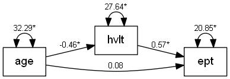

# Decomposing Effects and Covariances for Mediation Model

- RAMpath provides a flexible and efficient way to decompose each effect (direct or total effect) and covariance (variance or covariance) into individual components
- Based on Wright (1934) tracing rules
- Benefits
  - We can see the total effect between two variables
  - We can trace the variance of a variable to see what factors contribute to its variability
  - For any two variables, the covariance can be decomposed into individual components that contribute to the association between the two variables

```r
# ramPathBridge with indirect=TRUE calculates all individual paths
bridge <- ramPathBridge(res1, allbridge=TRUE, indirect=TRUE)

# summary displays the results of ramPathBridge
summary(bridge, se=TRUE)
```

```
## Path and its decomposions:
##
## Path Name                            Value           se    Pecent
## age > hvlt                  1       -0.463                 100.00
##   age > hvlt                  1       -0.463        0.138    100.00
## age > ept                   2       -0.187                 100.00
##   age > ept                   1        0.075        0.134    -40.13
##   age > hvlt > ept            2       -0.262        0.003    140.13
## hvlt > ept                  1        0.566                 100.00
##   hvlt > ept                  1        0.566        0.129    100.00
```

```r
summary(bridge, type="bridge")
```

```
## Covariance and its bridges:
##
## Path Name                                                Value   Percent
## age <> age                                      1       32.294    100.00
##   age <> age                                      1       32.294    100.00
## hvlt <> age                                     1      -14.959    100.00
##    hvlt < age <> age                              1      -14.959    100.00
## hvlt <> hvlt                                    2       34.570    100.00
##   hvlt <> hvlt                                    1       27.641     79.96
##    hvlt < age <> age> hvlt                        2        6.929     20.04
## ept <> age                                      2       -6.039    100.00
##    ept < age <> age                               1        2.423    -40.13
##    ept< hvlt  < age <> age                        2       -8.462    140.13
## ept <> hvlt                                     3       18.433    100.00
##    ept < hvlt <> hvlt                             1       15.635     84.83
##    hvlt < age <> age> ept                         2       -1.123     -6.09
##    hvlt < age <> age> hvlt > ept                  3        3.920     21.26
## ept <> ept                                      6       30.827    100.00
##   ept <> ept                                      1       20.853     67.65
##    ept < age <> age> ept                          2        0.182      0.59
##    ept< hvlt  < age <> age> ept                   3       -0.635     -2.06
##    ept < age <> age> hvlt > ept                   4       -0.635     -2.06
##    ept< hvlt  < age <> age> hvlt > ept            5        2.217      7.19
##    ept < hvlt <> hvlt> ept                        6        8.845     28.69
```

# Direct path from age to ept

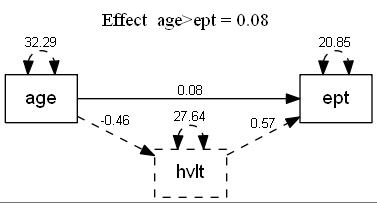

# Inirect path from age to ept

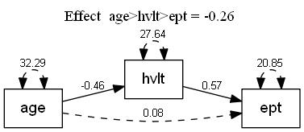